| output: html_document: pdf_document: default word_document: default title: “Fall 2020 - Math 421 - Midterm” |
| --- |

## I. Data Wranggling

```r
library(tidyverse)
library(rpart)
library(rattle)
```

```r
library(haven)
library(gganimate)
library(ggplot2)
library(knitr)
library(caret)
library(ranger)
```

1. Download the data file `hdd0318cy.sas7bdat`.
2. Use `read_sas` in library `haven` to read the data.

```r
df <- read_sas('C:\\Users\\student\\Documents\\Senior 1\\Stats R\\hdd0318cy (2).sas7bdat')
```

3. Filter the data to have only patients of the year 2018 (`yod==2018`)

```r
df1 <- filter(df, yod==18)
```

4. Select to work with only following variables:

```r
                      df1 <-  select(df1,"yod", "payfix","pay_ub92","age",
                      "sex","raceethn","provider","moa",
                      "yoa","mod","admtype", "asource" ,
                      "preopday" ,"los", "service" , "icu","ccu",
                      "dispub92", "payer"  ,"drg","trandb",
                      "randbg","randbs","orr", "anes","seq",
                      "lab","dtest", "ther","blood","phar",
                      "other","patcon","bwght","total","tot" ,
                      "ecodub92","b_wt","pt_state","diag_adm","ancilar" ,
                      "campus","er_fee","er_chrg","er_mode","obs_chrg",
                      "obs_hour","psycchrg","nicu_day")
```

*Notice*: You may want to save the current data to your computer for easy access later. To save the data file use `write_csv(df, 'midterm.csv')`, for example.

5. What are variables that have missing values?

```r
colSums(is.na(df1))
```

```
##      yod   payfix pay_ub92      age      sex raceethn provider      moa
##        0   131478        0        0        0        0        0        0
##      yoa      mod  admtype  asource preopday      los  service      icu
##        0        0        0        0    60486        0        0        0
##      ccu dispub92    payer      drg   trandb   randbg   randbs      orr
##        0        0        0        0        0        0        0        0
##     anes      seq      lab    dtest     ther    blood     phar    other
##        0        0        0        0        0        0        0        0
##   patcon    bwght    total      tot ecodub92     b_wt pt_state diag_adm
##        0        0        0        0        0        0        0        0
##  ancilar   campus   er_fee  er_chrg  er_mode obs_chrg obs_hour psycchrg
##        0        0        0        0        0        0    77343        0
## nicu_day
##   124090
```

6. Remove all variables with missing values

```r
df1$payfix <- NULL
df1$preopday <- NULL
df1$obs_hour <- NULL
df1$nicu_day <- NULL
```

7. Refer to the data description in the file `HDD2015-18cy6-20-19.docx`, which variable recording the month of admission?, which variable recording the month of discharge?

MOA is month of admission and MOD is month of discharge

```r
table(df1$moa)
```

```
##
##     1     2     3     4     5     6     7     8     9    10    11    12
## 11309 10259 11073 11174 11404 10690 10962 11199 10666 11408 10636 10698
```

```r
df1 %>%
  filter(sex == 1) %>%
  group_by(moa) %>%
  summarise(patients = n())
```

```
## # A tibble: 12 x 2
##      moa patients
##    <dbl>    <int>
##  1     1     4970
##  2     2     4546
##  3     3     4978
##  4     4     4989
##  5     5     5066
##  6     6     4810
##  7     7     4910
##  8     8     5028
##  9     9     4683
## 10    10     5164
## 11    11     4800
## 12    12     4855
```

9. Which month has the most number of teenage female patients?

```r
df1 %>%
   filter(sex == 2 & age %in% c(13:17)) %>%
  group_by(moa) %>%
  summarise(patients = n())
```

```
## # A tibble: 12 x 2
##      moa patients
##    <dbl>    <int>
##  1     1      139
##  2     2      111
##  3     3      158
##  4     4      123
##  5     5      150
##  6     6       97
##  7     7       97
##  8     8      105
##  9     9      131
## 10    10      126
## 11    11      128
## 12    12      131
```

10. Which provider has the most number of female patients in October? 7205

```r
df1 %>%
    filter(sex == 2 & moa == 10) %>%
  group_by(provider) %>%
  summarise(patients = n())
```

```
## # A tibble: 12 x 2
##    provider patients
##    <chr>       <int>
##  1 7201          294
##  2 7202          212
##  3 7204          872
##  4 7205         1517
##  5 7206          333
##  6 7209          351
##  7 7210          699
##  8 7211          122
##  9 7213          317
## 10 7214         1224
## 11 7215           46
## 12 7216          256
```

11. Is female patients older than male patients, on average?

```r
df1 %>%
  group_by(sex) %>%
  summarise(mean(age))
```

```
## # A tibble: 3 x 2
##   sex   `mean(age)`
##   <chr>       <dbl>
## 1 1            51.5
## 2 2            50.9
## 3 9            43
```

12. Calculate the average age of patients by months. Which month has the oldest patients on average age?

```r
df1 %>%
  group_by(moa) %>%
  summarise(mean(age))
```

```
## # A tibble: 12 x 2
##      moa `mean(age)`
##    <dbl>       <dbl>
##  1     1        51.8
##  2     2        51.2
##  3     3        51.1
##  4     4        51.4
##  5     5        50.6
##  6     6        51.5
##  7     7        51.3
##  8     8        50.9
##  9     9        50.6
## 10    10        50.8
## 11    11        51.0
## 12    12        51.5
```

```r
df1 %>%
  group_by(provider) %>%
  summarise(mean(tot))
```

```
## # A tibble: 12 x 2
##    provider `mean(tot)`
##    <chr>          <dbl>
##  1 7201          22775.
##  2 7202          35504.
##  3 7204          35277.
##  4 7205          48739.
##  5 7206          31018.
##  6 7209          24539.
##  7 7210          27691.
##  8 7211          24089.
##  9 7213          38200.
## 10 7214          22362.
## 11 7215          69946.
## 12 7216          17782.
```

```r
df1 %>%
  filter(sex=='1', age<20) %>%
  group_by(provider) %>%
  summarise(mean(tot))
```

```
## # A tibble: 12 x 2
##    provider `mean(tot)`
##    <chr>          <dbl>
##  1 7201           5720.
##  2 7202          29389.
##  3 7204          24989.
##  4 7205          33662.
##  5 7206          10360.
##  6 7209           9054.
##  7 7210           8608.
##  8 7211          19742.
##  9 7213          10970.
## 10 7214          25295.
## 11 7215          86525.
## 12 7216          24060.
```

15. Calculate the length of stays by races. Which race has the longest length of stays on average?

```r
df1 %>%
  group_by(raceethn) %>%
  summarise(mean(los))
```

```
## # A tibble: 8 x 2
##   raceethn `mean(los)`
##   <chr>          <dbl>
## 1 ""              4.38
## 2 "1"             4.93
## 3 "2"             5.28
## 4 "3"             4.41
## 5 "4"             5.54
## 6 "6"             5.35
## 7 "7"             4.67
## 8 "9"             6.18
```

16. On average, how much a 20 year-old male white get charged for staying 1 day?

```r
df1 %>%
  filter(sex=='1', age==20, raceethn=='1') %>%
  group_by(los) %>%
  summarise(mean(tot))
```

```
## # A tibble: 23 x 2
##      los `mean(tot)`
##    <dbl>       <dbl>
##  1     0      16350.
##  2     1      15320.
##  3     2      16970.
##  4     3      19682.
##  5     4      19351.
##  6     5      22237.
##  7     6      22549.
##  8     7      23893.
##  9     8      31584.
## 10     9      32680.
## # ... with 13 more rows
```

## II. Data Visualization

Continue with the data from part I.

1. Provides at least 10 meaningful plots. Comments on the plots. All plots should have title, caption, appropriate labels on x and y-axis

This compares the lenght of stay and month of admission, further divided by race.

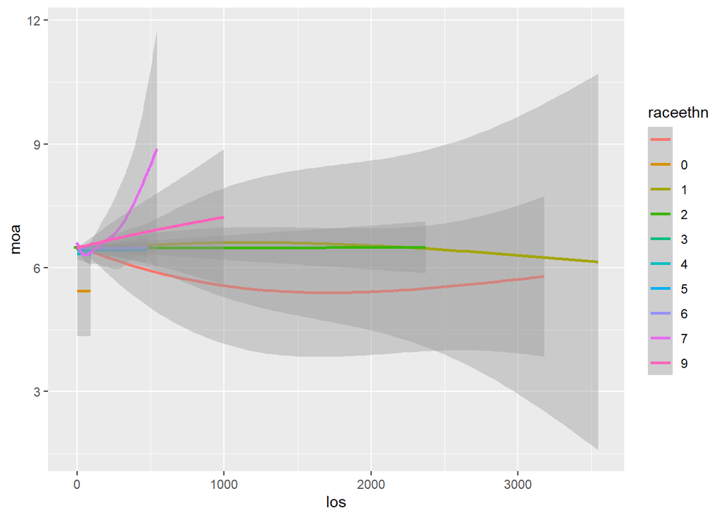

```r
df %>% ggplot()+
  geom_smooth(mapping = aes(x = los, y = moa, color = raceethn))
```

Next I wanted to see the month of admission by race to see how many people where admissioned when.

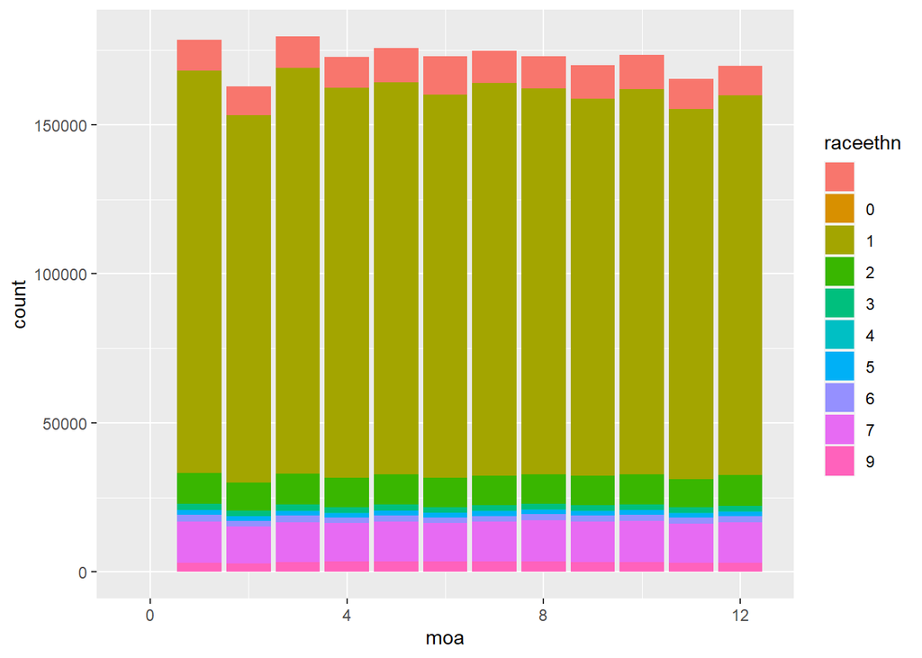

```r
df %>% ggplot()+
  geom_bar(mapping = aes(x = moa, fill = raceethn))
```

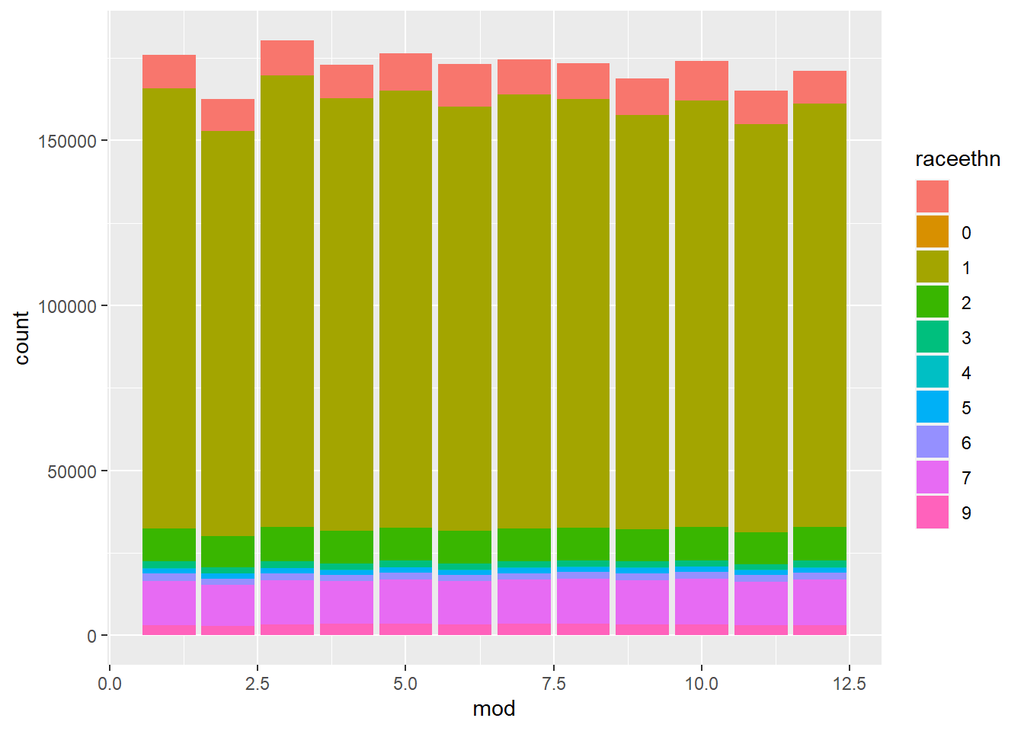

```r
df %>% ggplot()+
  geom_bar(mapping = aes(x = mod, fill = raceethn))
```

This graph compares moa and mod on the same graph to easily compare the two results.

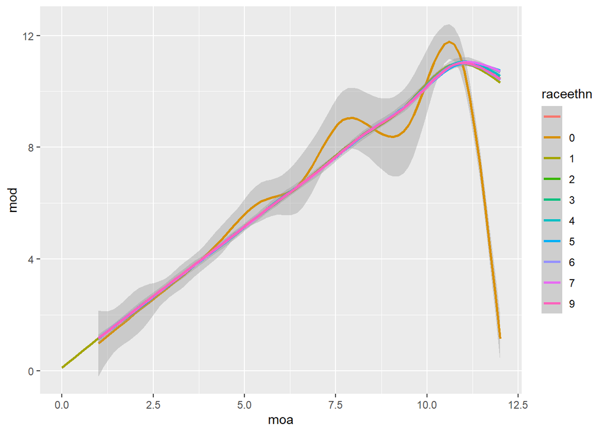

```r
df %>% ggplot()+
  geom_smooth(mapping = aes(x = moa, y = mod, color = raceethn))
```

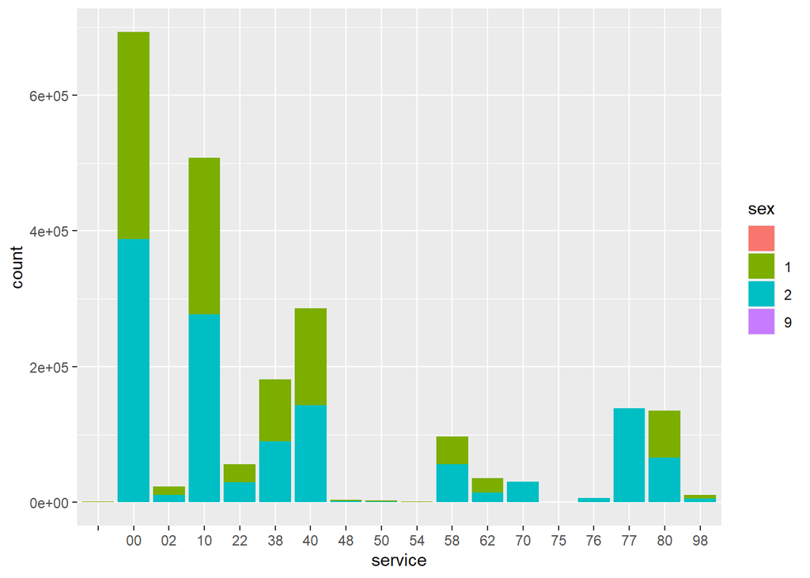

```r
df %>% ggplot()+
  geom_bar(mapping = aes(x = service, fill = sex))
```

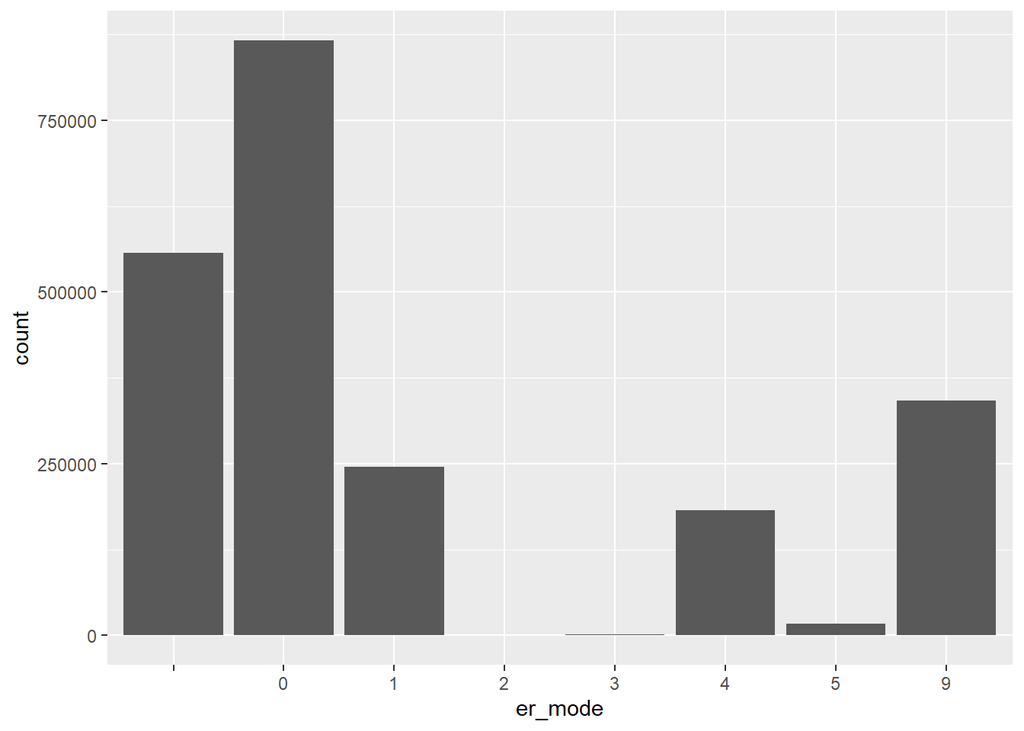

```r
df %>% ggplot()+
  geom_bar(mapping = aes(x = er_mode, fill = tot))
```

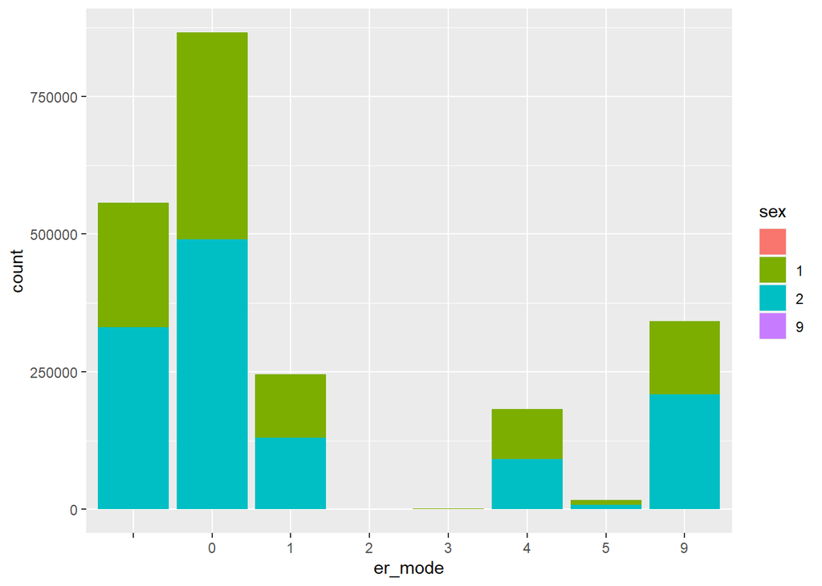

```r
df %>% ggplot()+
  geom_bar(mapping = aes(x = er_mode, fill = sex))
```

This grpah shows the relationship between total fee, and the payer, filtered to sex.

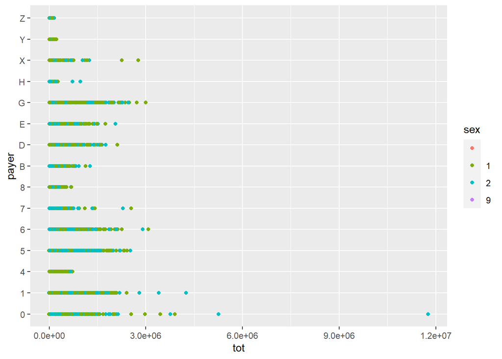

```r
df %>% ggplot()+
  geom_point(mapping = aes(x = tot, y = payer, color = sex))
```

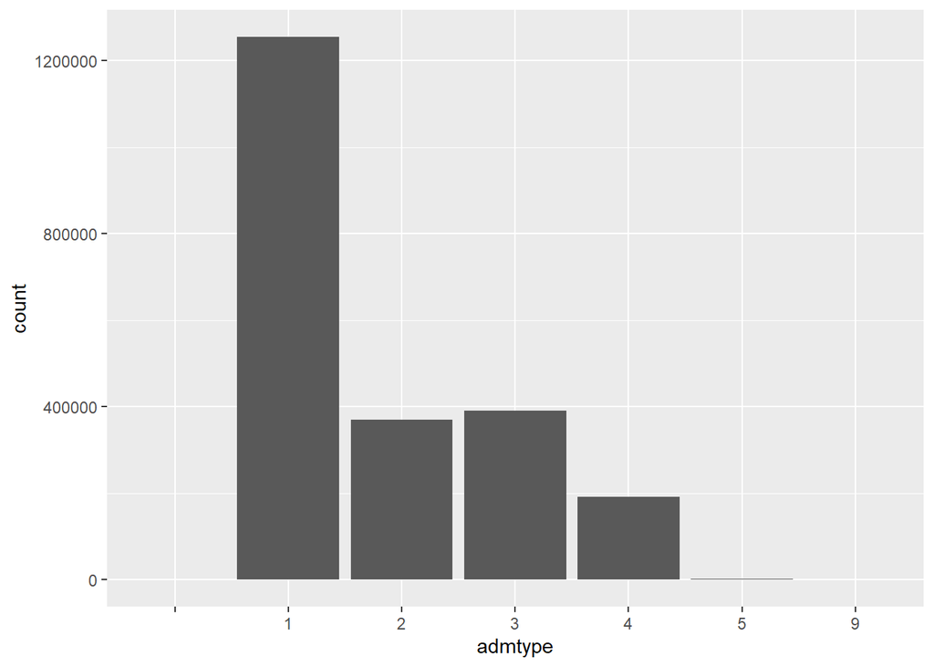

```r
df %>% ggplot()+
  geom_bar(mapping = aes(x = admtype, fill = tot))
```

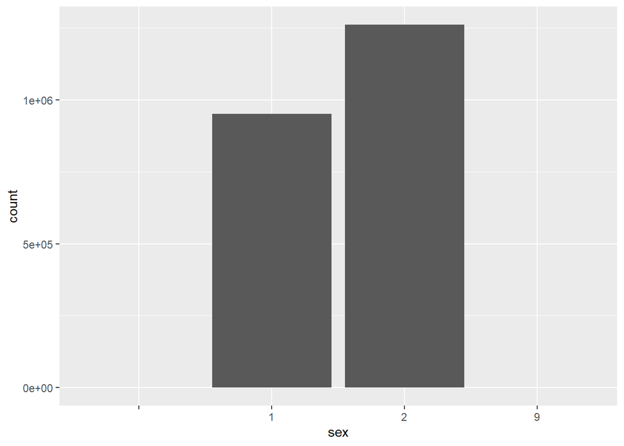

```r
df %>% ggplot()+
  geom_bar(mapping = aes(x = sex, fill = tot))
```

2. Make an animation

[figure not shown]

```r
p1 <- ggplot(df, aes(x=er_mode,
                 y=tot,
                 fill=tot)) +
  geom_col()+
  ylim(0, 2500)+
  transition_states(moa) +
labs(title = 'Total Charge by Month of Admission')
animate(p1, nframes=100, fps=20)
```

## III. Predictive Models

Continue with the data from part I. Use the follows as the target and input variables:

*Target Variable*: Create the target variable taking value of

- `low cost` if the total charge of a patient (`tot`) is smaller than the median of the total charge, and
- `high cost` otherwise.

*Input Variables*:

- “age”,“sex”,“raceethn”,“provider”,“moa”,“mod”,“admtype”,“campus”, ‘los’
1. Make sure all the categorical variables are factor, numeric variables are numeric. Set Training : Testing Split = 10 : 90

```r
df1$target <-  case_when(df1$tot <26896.54 ~ 'low cost',
  TRUE ~ 'high cost')
```

```r
df2 <- df1 %>%
  select(target,age,sex,raceethn,provider,moa,mod,admtype,campus,los)

df2$raceethn <- factor(df2$raceethn)
df2$provider <- factor(df2$provider)
df2$admtype <- factor(df2$admtype)
df2$campus <- factor(df2$campus)
df2$age <- factor(df2$age)
df2$moa <- factor(df2$moa)
df2$mod <- factor(df2$mod)
df2$sex <- factor(df2$sex)
df2$los <- factor(df2$los)
```

```r
set.seed(2018)
splitIndex <- createDataPartition(df2$target, p = .1,
                                  list = FALSE)
df2_train <- df2[ splitIndex,]
df2_test <- df2[-splitIndex,]
```

2. Train a decision tree using `rpart`. Plot the decision tree. Plot the variable importance ranked by the tree.

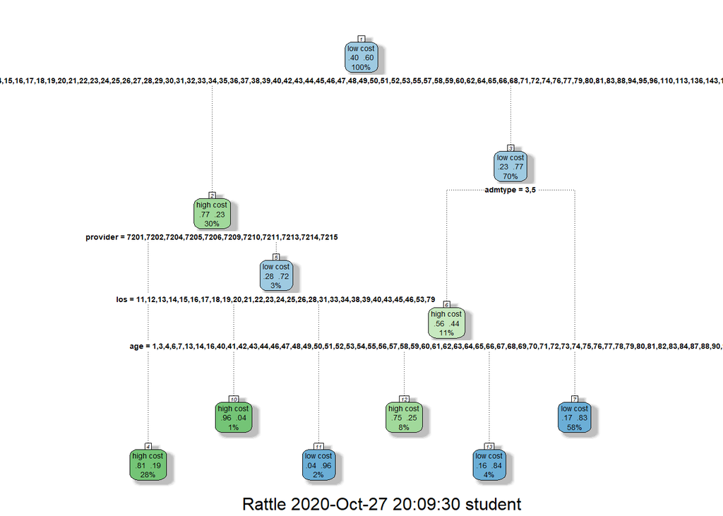

```r
tree_model <- rpart(target ~ ., data = df2_train,
                 control = rpart.control(maxdepth = 3))
fancyRpartPlot(tree_model)
```

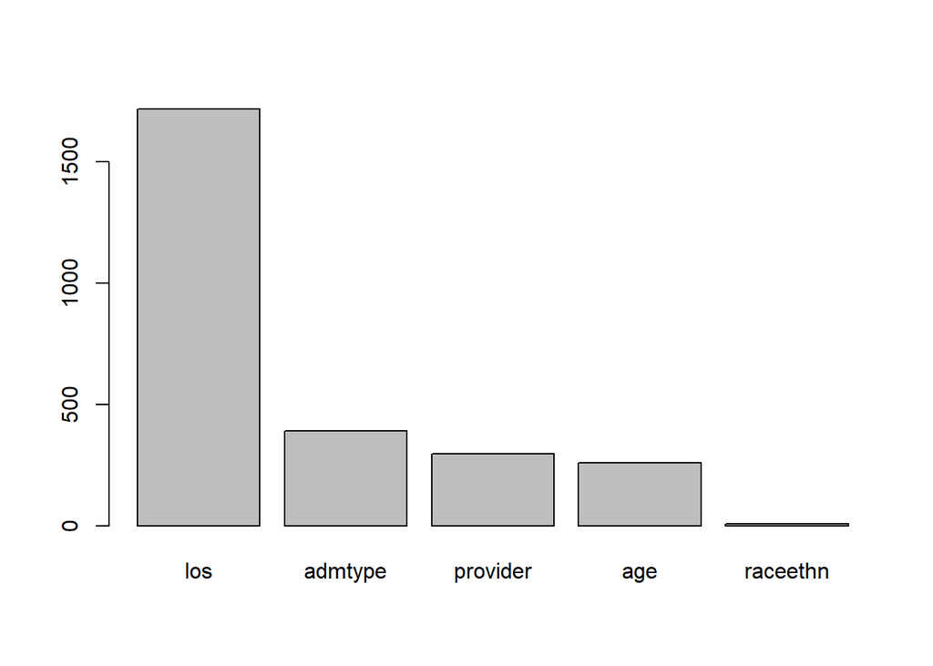

```r
barplot(tree_model$variable.importance)
```

3. Using caret for this question. Set `Training Control` to be: Use Cross-Validation of 5 folds across all models. Train & tune at least 3 different models (i.e. three different values for `method=` in the train function of caret). Plot the hyper-parameter tuning plots for each model.

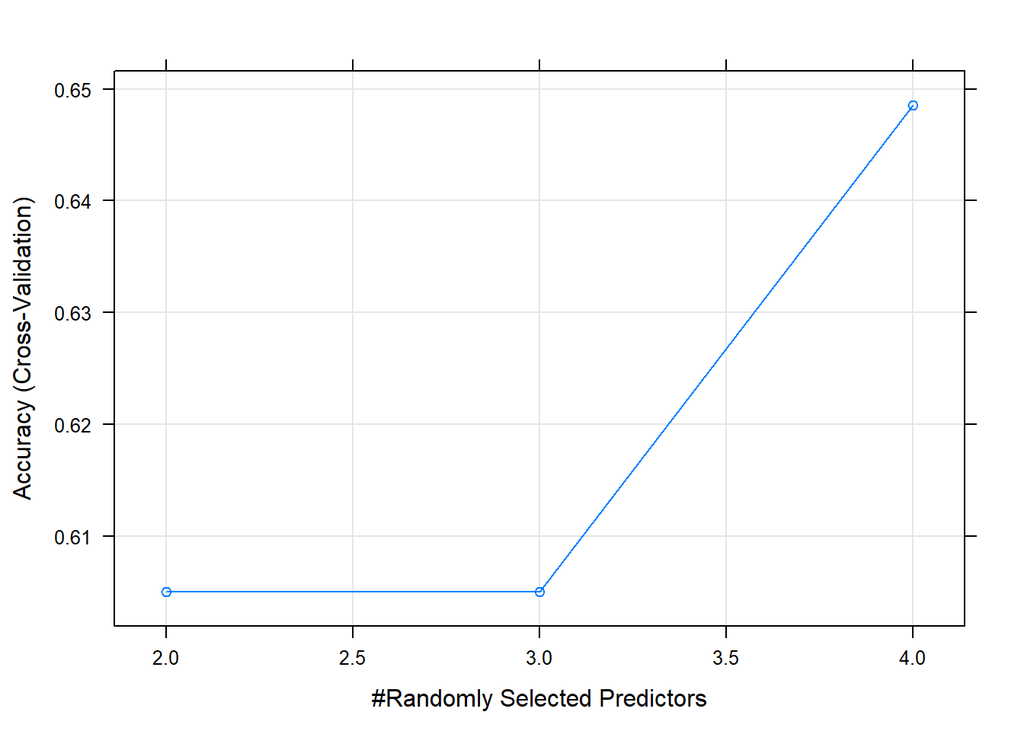

```r
tuneGrid <-  expand.grid(mtry = 2:4)
trControl <-  trainControl(method = "cv", number = 5)
forest_cv <- train(target~., data=df2_train,
                                method = "rf",
                                trControl = trControl,
                                tuneGrid = tuneGrid)
plot(forest_cv)
```

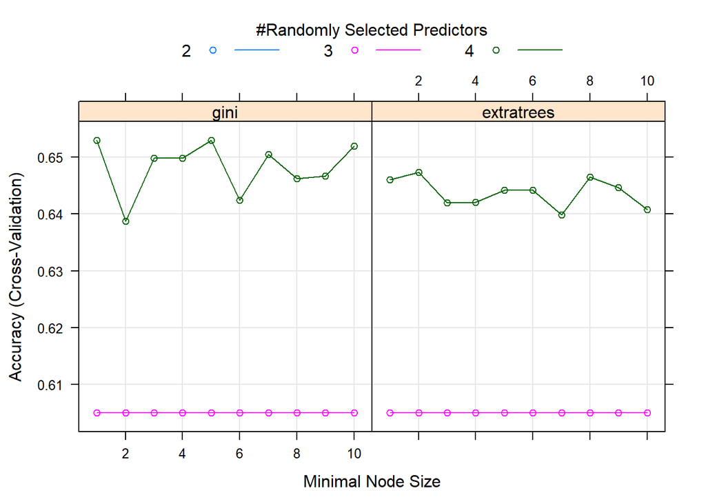

```r
tuneGrid1 <-  expand.grid(mtry = 2:4,
                       splitrule = c('gini', 'extratrees'),
                       min.node.size = c(1:10))
trControl1 <-  trainControl(method = "cv",
                            number = 5)
forest_cv1 <- train(target~., data=df2_train,
                                method = "ranger",
                                trControl = trControl1,
                                tuneGrid = tuneGrid1)
plot(forest_cv1)
```

```r
library(caTools)
```

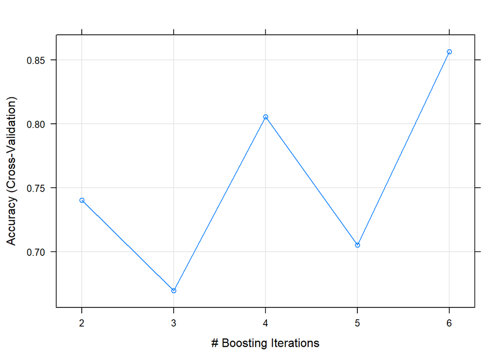

```r
tuneGrid2 <-  expand.grid(nIter = 2:6)
trControl2 <-  trainControl(method = "cv",
                            number = 5)
boost_model <- train(target~., data=df2_train,
                                method = "LogitBoost",
                                trControl = trControl2,
                                tuneGrid = tuneGrid2)
plot(boost_model)
```

4. Plot the comparison of the models in 2.

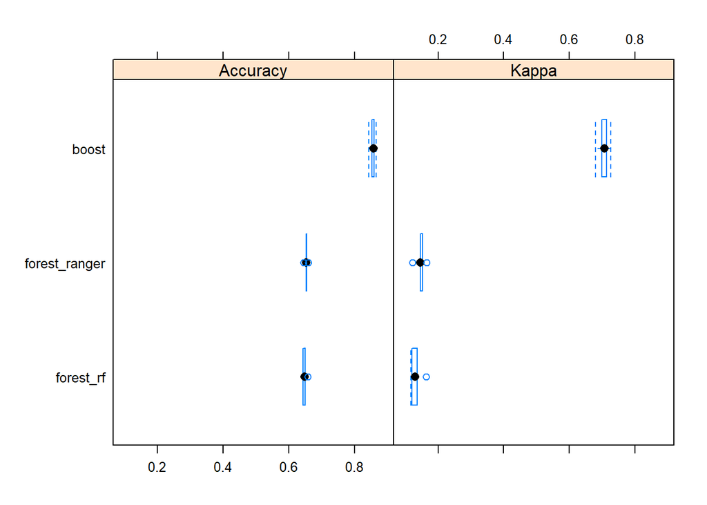

```r
results <- resamples(list(forest_rf = forest_cv,
                          forest_ranger = forest_cv1,
                          boost = boost_model))
bwplot(results)
```

5. What is your final selection for the model? Test the accuracy of your final model on the test data.

```r
pred <- predict(boost_model,df2_test)
cm <- confusionMatrix(data = factor(pred), reference = factor(df2_test$target), positive = "high cost")
cm$overall[1]
```

```
##  Accuracy
## 0.8625439
```

6. Create another `target` variable (binary), decide the input variables and redo 1 to 5.

```r
df1$target1 <- case_when(
  df1$age <18 ~ 'Child',
  TRUE ~ 'Adult')

df3 <- df1 %>%
  select(target1,sex,raceethn,provider,moa,mod,admtype,campus,los) %>%
  filter(admtype != '' & raceethn != '' & sex != 9)
df3$age <- NULL
str(df3)
```

```
## tibble [127,523 x 9] (S3: tbl_df/tbl/data.frame)
##  $ target1 : chr [1:127523] "Child" "Adult" "Adult" "Child" ...
##  $ sex     : chr [1:127523] "1" "2" "2" "1" ...
##   ..- attr(*, "label")= chr " patient sex (1=M,2=F) alpha"
##   ..- attr(*, "format.sas")= chr "$SEX"
##  $ raceethn: chr [1:127523] "1" "1" "1" "7" ...
##   ..- attr(*, "label")= chr " patient race/ethnicity"
##   ..- attr(*, "format.sas")= chr "$RACEETH"
##  $ provider: chr [1:127523] "7214" "7214" "7214" "7214" ...
##   ..- attr(*, "label")= chr " provider"
##   ..- attr(*, "format.sas")= chr "$PROVID"
##  $ moa     : num [1:127523] 1 1 12 1 12 12 1 1 1 12 ...
##   ..- attr(*, "label")= chr " month of admission  mm"
##   ..- attr(*, "format.sas")= chr "MONTHNME"
##  $ mod     : num [1:127523] 1 1 1 1 1 1 1 1 1 1 ...
##   ..- attr(*, "label")= chr " month of discharge  mm"
##   ..- attr(*, "format.sas")= chr "MONTHNME"
##  $ admtype : chr [1:127523] "4" "3" "2" "4" ...
##   ..- attr(*, "label")= chr " admission type"
##   ..- attr(*, "format.sas")= chr "$ADMTYPE"
##  $ campus  : chr [1:127523] "0" "0" "0" "0" ...
##  $ los     : num [1:127523] 2 1 3 4 35 17 2 3 2 12 ...
##   ..- attr(*, "label")= chr " length of stay,in days for hosp[in hours for ED"
##  - attr(*, "label")= chr "HDD0318CY                       "
```

```r
df3$raceethn <- factor(df3$raceethn)
df3$provider <- factor(df3$provider)
df3$admtype <- factor(df3$admtype)
df3$campus <- factor(df3$campus)
df3$moa <- factor(df3$moa)
df3$mod <- factor(df3$mod)
df3$sex <- factor(df3$sex)
df3$los <- factor(df3$los)
```

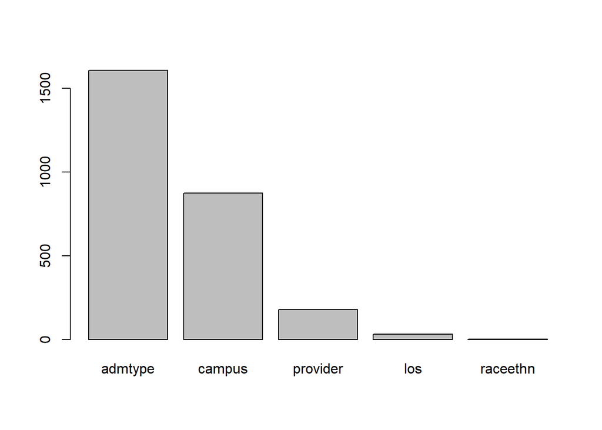

```r
set.seed(2020)

splitIndex <- createDataPartition(df3$target1, p = .10,
                                  list = FALSE)
df3_train<- df3[ splitIndex,]
df3_test <- df3[-splitIndex,]


tree_model3 <- rpart(target1 ~ ., data = df3_train,
                 control = rpart.control(maxdepth = 3))
barplot(tree_model3$variable.importance)
```

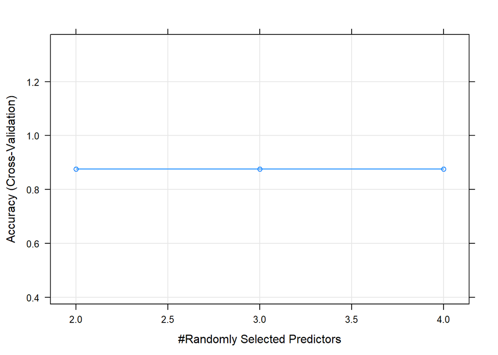

```r
tuneGrid <-  expand.grid(mtry = 2:4)
trControl <-  trainControl(method = "cv", number = 5)
forest_cv2 <- train(target1~., data=df3_train,
                                method = "rf",
                                trControl = trControl,
                                tuneGrid = tuneGrid)
plot(forest_cv2)
```

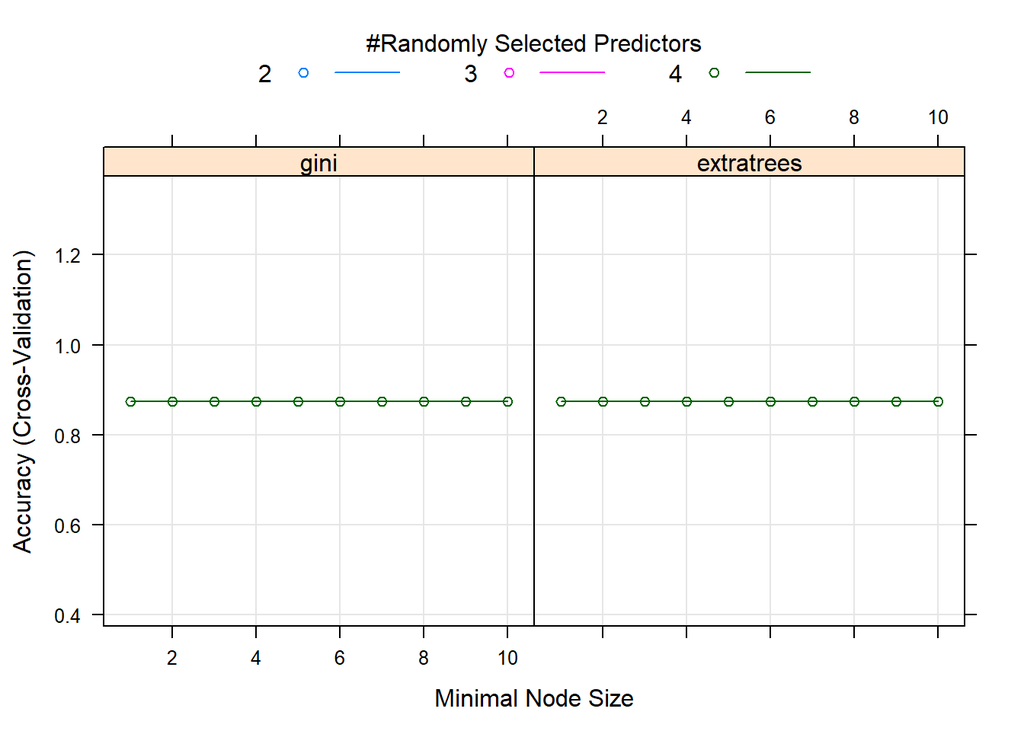

```r
tuneGrid1 <-  expand.grid(mtry = 2:4,
                       splitrule = c('gini', 'extratrees'),
                       min.node.size = c(1:10))
trControl1 <-  trainControl(method = "cv",
                            number = 5)
forest_cv3 <- train(target1~., data=df3_train,
                                method = "ranger",
                                trControl = trControl1,
                                tuneGrid = tuneGrid1)
plot(forest_cv3)
```

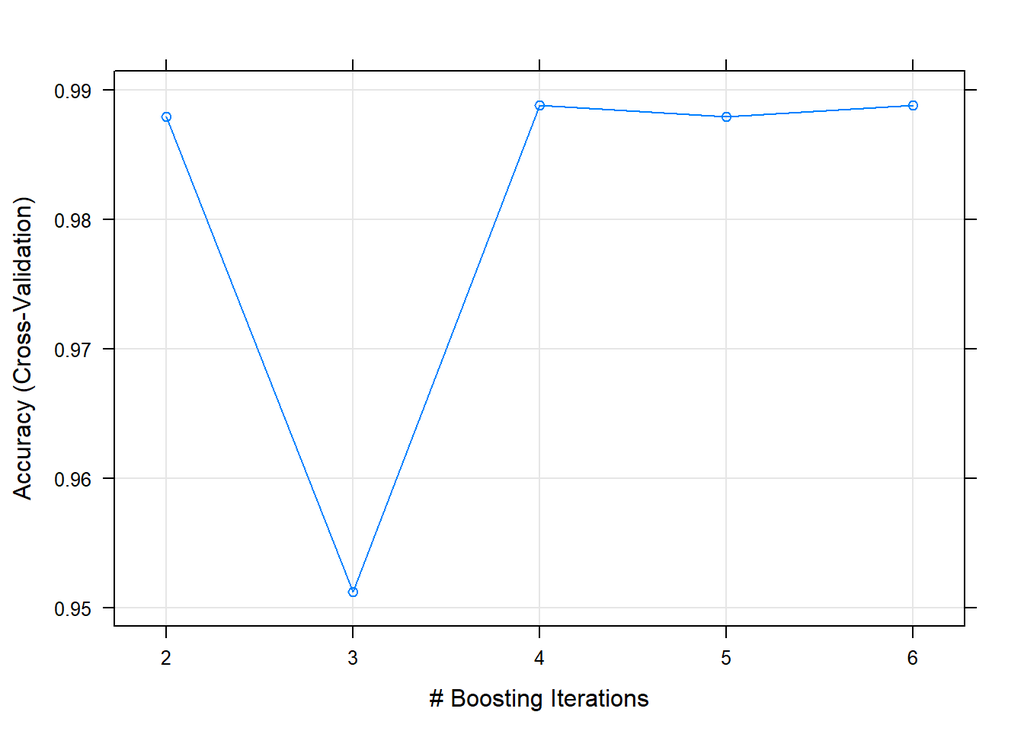

```r
tuneGrid2 <-  expand.grid(nIter = 2:6)
trControl2 <-  trainControl(method = "cv",
                            number = 5)
boost_model2 <- train(target1~., data=df3_train,
                                method = "LogitBoost",
                                trControl = trControl2,
                                tuneGrid = tuneGrid2)
plot(boost_model2)
```

```r
pred1 <- predict(boost_model2,df3_test)
cm1 <- confusionMatrix(data = pred1, reference = factor(df3_test$target1), positive = "Child")
cm1$overall[1]
```

```
##  Accuracy
## 0.9874955
```